# Exploratory Data Analysis

Serum Creatinine Cohort - NHANES Cycle L (2021-2023)

Silvia Duque Moro

```r
library(ggplot2)
library(dplyr)
library(patchwork)
library(kableExtra)
```

## Introduction & Objective

The clinical objective of this study is to model and predict Serum Creatinine (LBXSCR), a critical metabolic byproduct cleared by the kidneys. Accurately estimating creatinine levels based on non-invasive clinical phenotypes serves as a reliable proxy for evaluating overall renal clearance and detecting early signs of Chronic Kidney Disease (CKD).

## Cohort Profile & Sample Description

```r
# Load the clean dataset
df <- read.csv("../nhanes_final.csv")
```

The final study cohort consists of 3,226 observations.

### Target Variable Analysis: Serum Creatinine (LBXSCR)

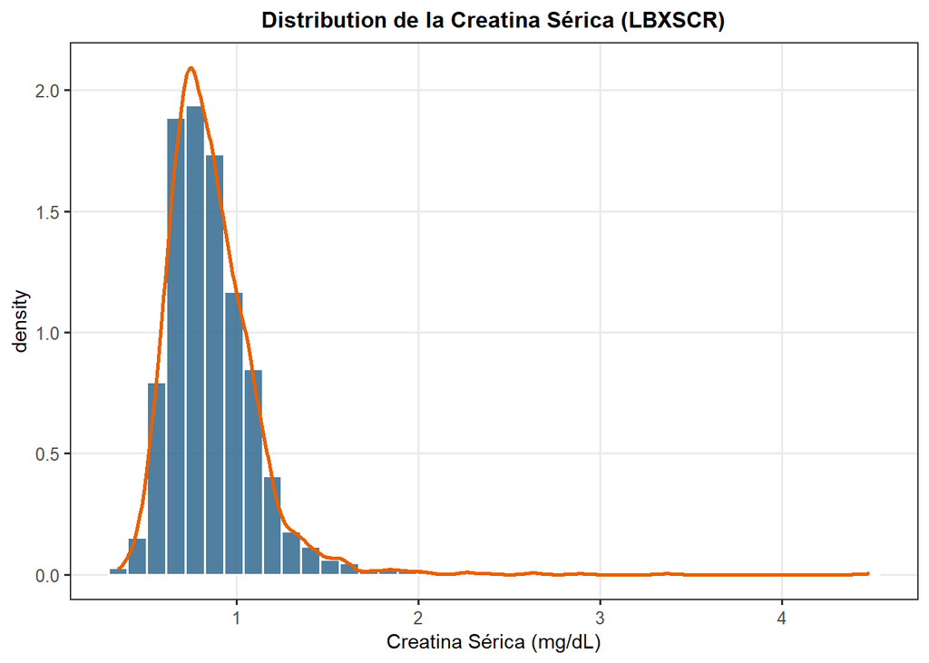

```r
ggplot(df, aes(x = LBXSCR)) +
  geom_histogram(aes(y = after_stat(density)),
                 fill = "#31688E",
                 color = "white",
                 alpha = 0.85,
                 bins = 40) +
  geom_density(color = "#E66101", linewidth = 1) +
  labs(title = "Distribution de la Creatina Sérica (LBXSCR)",
       x = "Creatina Sérica (mg/dL)") +
  theme_bw(base_size = 12) +
  theme(
    plot.title = element_text(face = "bold", size = 12, hjust = 0.5),
    axis.title = element_text(size = 11),
    panel.grid.minor = element_blank()
  )
```

### Analysis of Variables

This section details the distributions of the physiological and clinical variables used to predict serum creatinine levels.

The dataset comprises 54.1% females and 45.9% males, with a mean age of 49.45 years (ranging from 12 to 80). The cohort presents a high metabolic and chronic risk profile: the mean Body Mass Index (BMI) is $28.90 \text{ kg/m}^2$, mean waist circumference is $98.55 \text{ cm}$, 33.1% of individuals have hypertension, and 11.7% have diabetes. Additionally, 65.3% of the sample takes prescription medication, with an average of 2.02 drugs per person.

```r
var_continuas <- c("LBXSCR", "LBXSAL", "LBXSTP", "LBXSUA", "LBXSTR", "LBXGLU",
    "LBXSCH", "LBXSCA", "LBXSPH", "LBXGH", "RIDAGEYR", "BMXBMI", "BMXWAIST",
    "BPXOSY1", "n_rx")

tabla_continua <- df %>%
  select(var_continuas) %>%
  summarise(across(everything(), list(
    Media     = ~ mean(.),
    DE        = ~ sd(.),
    Min       = ~ min(.),
    Mediana   = ~ median(.),
    Max       = ~ max(.),
    Asimetria = ~ moments::skewness(.)
  ))) %>%
  tidyr::pivot_longer(
    cols = everything(),
    names_to = c("Variable", ".value"),
    names_pattern = "(.*)_(.*)"
  )

tabla_continua %>%
  kable(
    booktabs = TRUE,
    digits = 2,
    # col.names = c("Variable", "Media", "DE", "Min.", "Mediana", "Máx.", "Asimetría"),
    align = c("l", "c", "c", "c", "c", "c", "c")
  ) %>%
  kable_styling(latex_options = c("hold_position", "striped", "scale_down"))
```

| Variable | Media | DE | Min | Mediana | Max | Asimetria |
| --- | --- | --- | --- | --- | --- | --- |
| LBXSCR | 0.86 | 0.25 | 0.35 | 0.82 | 4.48 | 2.71 |
| LBXSAL | 4.08 | 0.33 | 2.40 | 4.10 | 5.30 | -0.34 |
| LBXSTP | 7.15 | 0.43 | 5.00 | 7.10 | 9.00 | 0.04 |
| LBXSUA | 5.18 | 1.40 | 1.90 | 5.10 | 13.20 | 0.66 |
| LBXSTR | 117.66 | 85.59 | 24.00 | 97.00 | 1724.00 | 6.24 |
| LBXGLU | 107.71 | 32.18 | 59.00 | 100.00 | 561.00 | 4.97 |
| LBXSCH | 185.51 | 42.92 | 63.00 | 182.00 | 416.00 | 0.58 |
| LBXSCA | 9.41 | 0.37 | 7.50 | 9.40 | 11.20 | 0.00 |
| LBXSPH | 3.54 | 0.53 | 1.80 | 3.50 | 5.70 | 0.42 |
| LBXGH | 5.69 | 0.99 | 3.20 | 5.50 | 13.70 | 3.46 |
| RIDAGEYR | 49.45 | 20.40 | 12.00 | 53.00 | 80.00 | -0.31 |
| BMXBMI | 28.90 | 6.94 | 12.90 | 27.75 | 67.80 | 0.96 |
| BMXWAIST | 98.55 | 17.24 | 56.40 | 97.50 | 177.20 | 0.46 |
| BPXOSY1 | 120.15 | 17.98 | 75.00 | 117.00 | 224.00 | 0.94 |
| n_rx | 2.02 | 1.95 | 0.00 | 1.00 | 6.00 | 0.42 |

```r
tabla_categorica <- df %>%
  select(!all_of(var_continuas)) %>%
  mutate(across(everything(), as.character)) %>%
  tidyr::pivot_longer(cols = everything(), names_to = "Variable",
  values_to = "Categoria") %>%
  group_by(Variable) %>%
  count(Categoria, name = "N") %>%
  mutate(Porcentaje = (N / sum(N)) * 100) %>%
  ungroup()

tabla_categorica %>%
  kable(
    booktabs = TRUE,
    digits = 1,
    col.names = c("Variable", "Categoría / Valor", "Frecuencia (N)", "Porcentaje (%)"),
    align = c("l", "c", "c", "c")
  ) %>%
  collapse_rows(columns = 1, latex_hline = "major") %>%
  kable_styling(latex_options = c("hold_position", "striped"))
```

| Variable | Categoría / Valor | Frecuencia (N) | Porcentaje (%) |
| --- | --- | --- | --- |
| RIAGENDR | 1 | 1482 | 45.9 |
|  | 2 | 1744 | 54.1 |
| RIDRETH3 | Mexican American | 264 | 8.2 |
|  | Non-Hispanic Asian | 183 | 5.7 |
|  | Non-Hispanic Black | 340 | 10.5 |
|  | Non-Hispanic White | 1882 | 58.3 |
|  | Other Hispanic | 361 | 11.2 |
|  | Other Race - Including Multi-Racial | 196 | 6.1 |
| any_rx | 0 | 1120 | 34.7 |
|  | 1 | 2106 | 65.3 |
| ckd_self_rpt | 0 | 3067 | 95.1 |
|  | 1 | 159 | 4.9 |
| diabetes_dx | 0 | 2848 | 88.3 |
|  | 1 | 378 | 11.7 |
| htn_dx | 0 | 2158 | 66.9 |
|  | 1 | 1068 | 33.1 |
| rx_antidiab_oral | 0 | 2895 | 89.7 |
|  | 1 | 331 | 10.3 |
| rx_antihtn_proxy | 0 | 2235 | 69.3 |
|  | 1 | 991 | 30.7 |
| rx_insulin | 0 | 3118 | 96.7 |
|  | 1 | 108 | 3.3 |

## Bivariate Analysis

To understand the conditional distribution of serum creatinine, we evaluate its relationship with key clinical covariates. Given the high dimensionality of the dataset, this exploratory analysis focuses on a targeted subset of predictors.

The stratified analysis reveals that males exhibit systematically higher serum creatinine levels than females, reflecting the baseline physiological difference in average skeletal muscle mass. Additionally, a subtle but progressive upward shift in creatinine levels is visible as the number of prescribed medications increases, accompanied by a higher density of extreme outliers among polymedicated individuals.

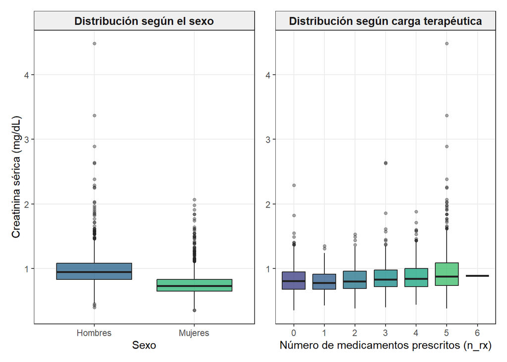

```r
# Gráfico Creatinina vs Sexo
g_sexo <- ggplot(df, aes(x = recode(factor(RIAGENDR), "1" = "Hombres", "2" = "Mujeres"),
                         y = LBXSCR,
                         fill = factor(RIAGENDR))) +
  geom_boxplot(alpha = 0.8, color = "#222222", outlier.alpha = 0.4, outlier.size = 1.2) +
  scale_fill_manual(values = c("1" = "#31688E", "2" = "#35B779")) +
  labs(
    x = "Sexo",
    y = "Creatinina sérica (mg/dL)"
  ) +
  facet_wrap(~ "Distribución según el sexo") +
  theme_bw(base_size = 11) +
  theme(
    strip.text = element_text(face = "bold", size = 11),
    strip.background = element_rect(fill = "#EFEFEF", color = "#222222"),
    panel.grid.minor = element_blank(),
    legend.position = "none"
  )

# Gráfico Creatinina vs Medicamentos
g_meds <- ggplot(df, aes(x = factor(n_rx), y = LBXSCR, fill = factor(n_rx))) +
  geom_boxplot(alpha = 0.8, color = "#222222", outlier.alpha = 0.4, outlier.size = 1.2) +
  scale_fill_viridis_d(option = "D", begin = 0.2, end = 0.8) +
  labs(
    x = "Número de medicamentos prescritos (n_rx)",
    y = NULL
  ) +
  facet_wrap(~ "Distribución según carga terapéutica") +
  theme_bw(base_size = 11) +
  theme(
    strip.text = element_text(face = "bold", size = 11),
    strip.background = element_rect(fill = "#EFEFEF", color = "#222222"),
    panel.grid.minor = element_blank(),
    legend.position = "none"
  )

figura_final <- g_sexo + g_meds

figura_final
```